# Exploratory Data Analysis - Diamond Prices

Casandra Philipson

February 12, 2016

### Load the dataset and figure out the basic structure.

```r
library(ggplot2)
```

We find that the dataset has the following observations:  
carat, cut, color, clarity, depth, table, price, x, y, z

There are 3 ordered factors in the dataset (cut, color, and clarity). Their ranks can be determined using:

```
factor(diamonds$cut)
factor(diamonds$color)
factor(diamonds$clarity)
```

Using factor() we find out the following scales:  
**Levels cut**: Fair < Good < Very Good < Premium < Ideal  
**Levels color**: D > E > F > G > H > I > J  
**Levels clarity**: I1 < SI2 < SI1 < VS2 < VS1 < VVS2 < VVS1 < IF

# Create a histogram of the price of all diamonds in the dataset

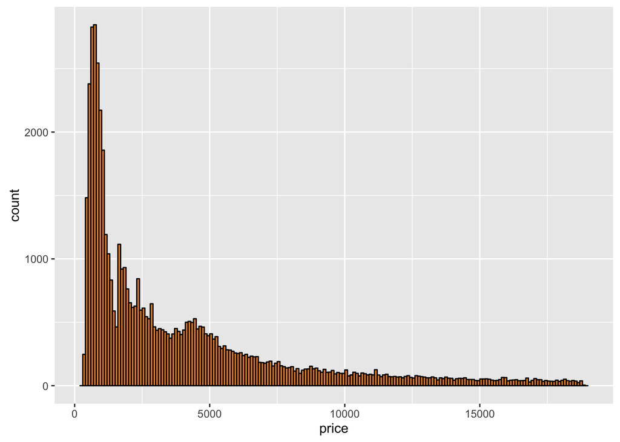

```r
qplot(x = price, data = diamonds, binwidth = 100,
      color = I('#000000'), fill = I('#F79420'))
```

This dataset has a right-tailed distribution with a median = 2401 and mean = 3933.

### How many diamonds fall into different price categories?

```r
diamonds$cost_250 <- NA
diamonds$cost_250 <- ifelse(diamonds$price < 250, 1, 0)

diamonds$cost_500 <- NA
diamonds$cost_500 <-ifelse(diamonds$price < 500, 1, 0)

diamonds$cost_15000 <- NA
diamonds$cost_15000 <-ifelse(diamonds$price >= 15000, 1, 0)
```

There are 0 diamonds valued under $250.  
There are 1729 diamonds valued under $500.  
There are 1656 diamonds valued at $15000 or greater.

### Explore the largest peak in the price histogram

Try to limit the x-axis, alter the bin width, and setting different breaks in the x-axis to see if you can get more info on this bracket.

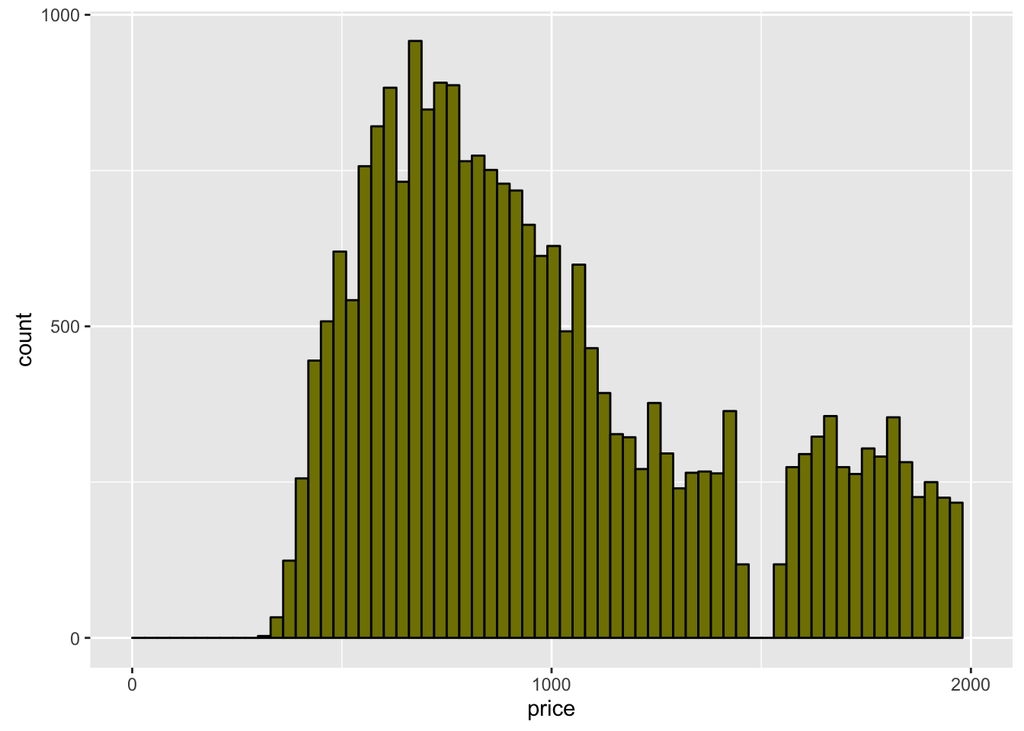

```r
qplot(x = price, data = diamonds, binwidth = 30,
      color = I('#000000'), fill = I('#808000')) +
  scale_x_continuous(breaks = seq(0, 2000, 1000), lim = c(0,2000)) +
  scale_y_continuous(breaks = seq(0, 3500, 500))
```

```r
library(dplyr)
diamond_subset <- filter(diamonds, price < 1500)
summary(diamond_subset[1:7])
```

```
##      carat               cut       color       clarity         depth
##  Min.   :0.2000   Fair     : 266   D:2848   VS2    :4514   Min.   :51.00
##  1st Qu.:0.3100   Good     :1548   E:4360   SI1    :4279   1st Qu.:61.10
##  Median :0.3400   Very Good:4186   F:3617   VS1    :3196   Median :61.80
##  Mean   :0.3677   Premium  :4492   G:4351   VVS2   :2595   Mean   :61.73
##  3rd Qu.:0.4100   Ideal    :9518   H:2683   VVS1   :2360   3rd Qu.:62.40
##  Max.   :1.0300                    I:1543   SI2    :1741   Max.   :78.20
##                                    J: 608   (Other):1325
##      table           price
##  Min.   :44.00   Min.   : 326.0
##  1st Qu.:56.00   1st Qu.: 630.0
##  Median :57.00   Median : 805.0
##  Mean   :57.01   Mean   : 841.4
##  3rd Qu.:58.00   3rd Qu.:1024.0
##  Max.   :70.00   Max.   :1454.0
##
```

It seems like most of the diamonds that cost under $1500 are around 0.35 carats!

```
remember you can save your figures using ggsave('priceHistogram.png')
```

### Plot data for diamond prices based on cut as separate histograms

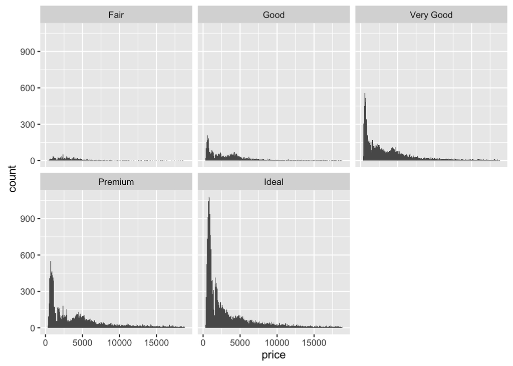

```r
library(gridExtra)

qplot(x = price, data = diamonds, binwidth = 75) +
  facet_wrap(~cut)
```

```r
diamonds %>% filter(price == max(price))
```

```
## Source: local data frame [1 x 13]
##
##   carat     cut  color clarity depth table price     x     y     z
##   (dbl)  (fctr) (fctr)  (fctr) (dbl) (dbl) (int) (dbl) (dbl) (dbl)
## 1  2.29 Premium      I     VS2  60.8    60 18823   8.5  8.47  5.16
## Variables not shown: cost_250 (dbl), cost_500 (dbl), cost_15000 (dbl)
```

```r
diamonds %>% filter(price == min(price))
```

```
## Source: local data frame [2 x 13]
##
##   carat     cut  color clarity depth table price     x     y     z
##   (dbl)  (fctr) (fctr)  (fctr) (dbl) (dbl) (int) (dbl) (dbl) (dbl)
## 1  0.23   Ideal      E     SI2  61.5    55   326  3.95  3.98  2.43
## 2  0.21 Premium      E     SI1  59.8    61   326  3.89  3.84  2.31
## Variables not shown: cost_250 (dbl), cost_500 (dbl), cost_15000 (dbl)
```

```r
by(diamonds$price, diamonds$cut, summary)
```

```
## diamonds$cut: Fair
##    Min. 1st Qu.  Median    Mean 3rd Qu.    Max.
##     337    2050    3282    4359    5206   18570
## --------------------------------------------------------
## diamonds$cut: Good
##    Min. 1st Qu.  Median    Mean 3rd Qu.    Max.
##     327    1145    3050    3929    5028   18790
## --------------------------------------------------------
## diamonds$cut: Very Good
##    Min. 1st Qu.  Median    Mean 3rd Qu.    Max.
##     336     912    2648    3982    5373   18820
## --------------------------------------------------------
## diamonds$cut: Premium
##    Min. 1st Qu.  Median    Mean 3rd Qu.    Max.
##     326    1046    3185    4584    6296   18820
## --------------------------------------------------------
## diamonds$cut: Ideal
##    Min. 1st Qu.  Median    Mean 3rd Qu.    Max.
##     326     878    1810    3458    4678   18810
```

Interestingly the distribution of price looks similaar for diamonds of very good, premium, and ideal quality.

We also see that the highest price diamond is premium cut. The lowest price diamond is a tie between premium and ideal cuts. Finally, the lowest median price is found in the ideal cut category.

### Let’s look at the distributions again, make y-axis flexible

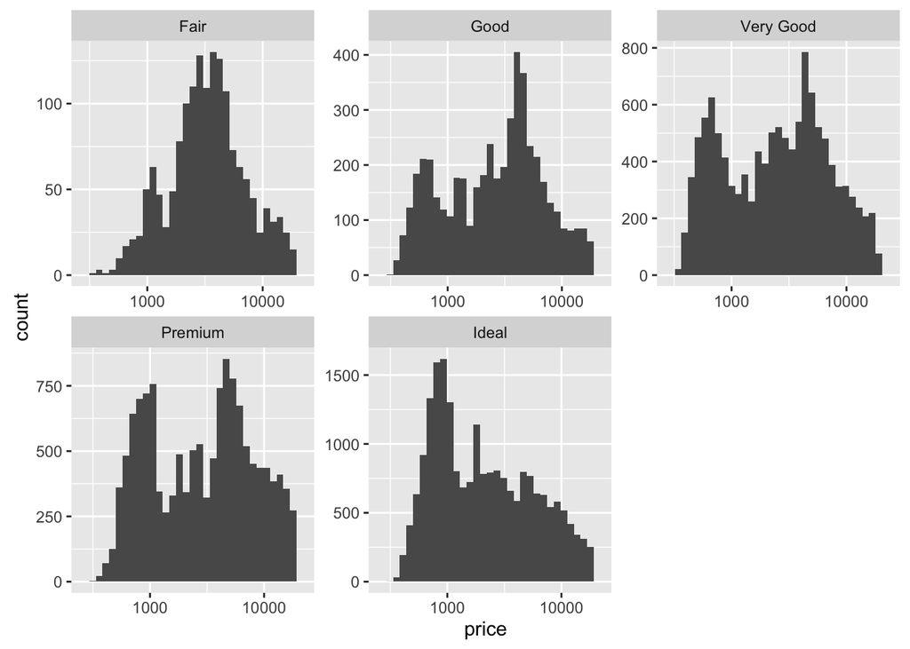

```r
qplot(x = price, data = diamonds, bins = 30) +
  facet_wrap(~cut, scales = "free") +
  scale_x_log10()
```

### Create a histogram of price per carat and facet it by cut

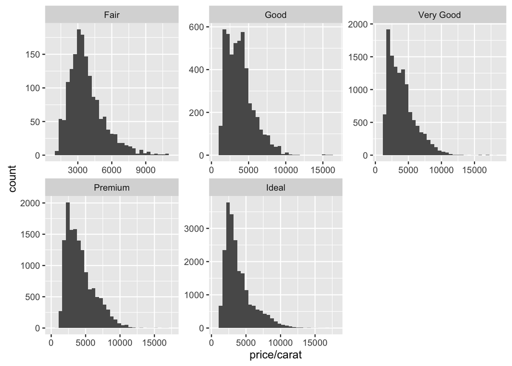

```r
qplot(x = price/carat, data = diamonds) +
  facet_wrap(~cut, scales = "free")
```

### Investigate the price per carat of diamons across different colors using boxplots

Create a plot based on calculated price/carat separated by color. Investigate the IQR.

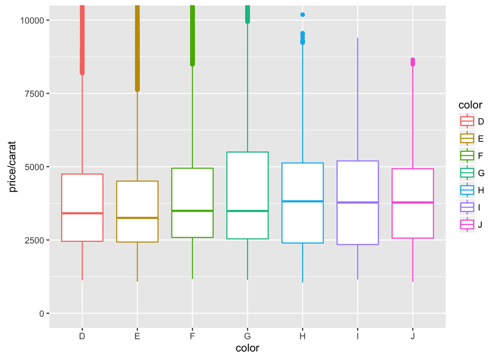

```r
qplot(x = color, y = price/carat, data = diamonds,
      geom = 'boxplot', color = color) +
    coord_cartesian(ylim = c(0, 10000))
```

```r
IQR(subset(diamonds, color == 'J' )$price)
```

```
## [1] 5834.5
```

```r
IQR(subset(diamonds, color == 'D' )$price)
```

```
## [1] 3302.5
```

### Investigate the weight of the diamonds (carat) using a frequency polygon.

Vary the different bin widths to find which carat size has a count greater than 2000.

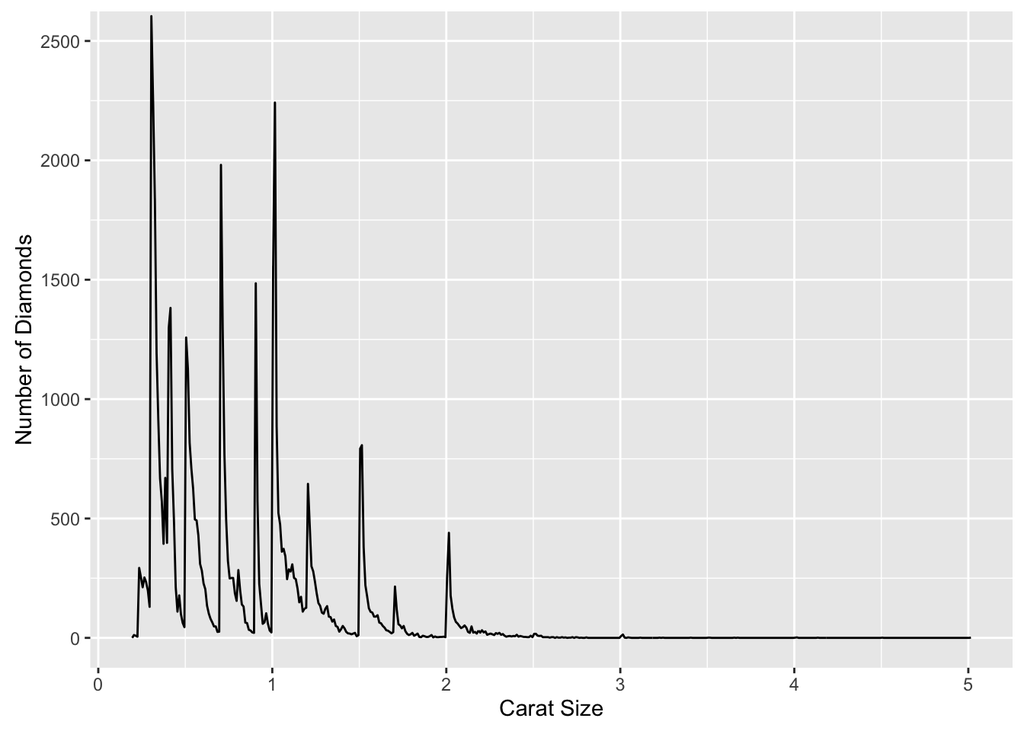

```r
qplot(x = carat, data = diamonds,
      binwidth = 0.01,
      geom = 'freqpoly',
      xlab = 'Carat Size',
      ylab = 'Number of Diamonds',
      color = carat) +
  coord_cartesian(ylim = c(0, 2500))
```

```r
table(diamonds$carat)[table(diamonds$carat)>2000]
```

```
##
##  0.3 0.31 1.01
## 2604 2249 2242
```